# The shifting social geographical distribution of road safety for cyclists: a case study of West Yorkshire

References to include:

- ([Schepers, 2012](http://injuryprevention.bmj.com/content/18/4/240.abstract))
- (Elvik et al., 2009)
- ([Short and Caulfield, 2014](http://www.sciencedirect.com/science/article/pii/S0967070X14000699))
- ([Wegman et al., 2012](http://www.sciencedirect.com/science/article/pii/S0001457510003416))
- ([Parkin et al., 2007](http://www.sciencedirect.com/science/article/pii/S0001457506001473))

## Abstract

# Introduction

West Yorkshire is not an area associated with cycling. Although the cities of York and Hull have traditionally high rates of cycling, Leeds and Bradford have historically low levels of active travel and heavily car orientated urban plans. In recent years there have been efforts to ammend this situation, and even calls for Leeds (traditionally known as the 'Motorway city') to become a 'cycling city'. This aspiration received a boost with the publication of 2011 census data showing that Leeds has seen cycling grow substantially (by 0.5 percentage points), from 1.4% to 1.9% in 2011. To put this growth in the national context, Leeds ranks 34th out of all 324 Enlgish Local Authorities in terms of cycling and 13th when London is excluded. In terms of Northern cities, Leeds has seen the fourth greatest shift to cycling, trailing only Newcastle, Manchester and Sheffield. Unfortunately, cycling has declined in the other Local Authorities within West Yorkshire, leading to a highly uneven spatial distribution of cycling across the county (figure 1).

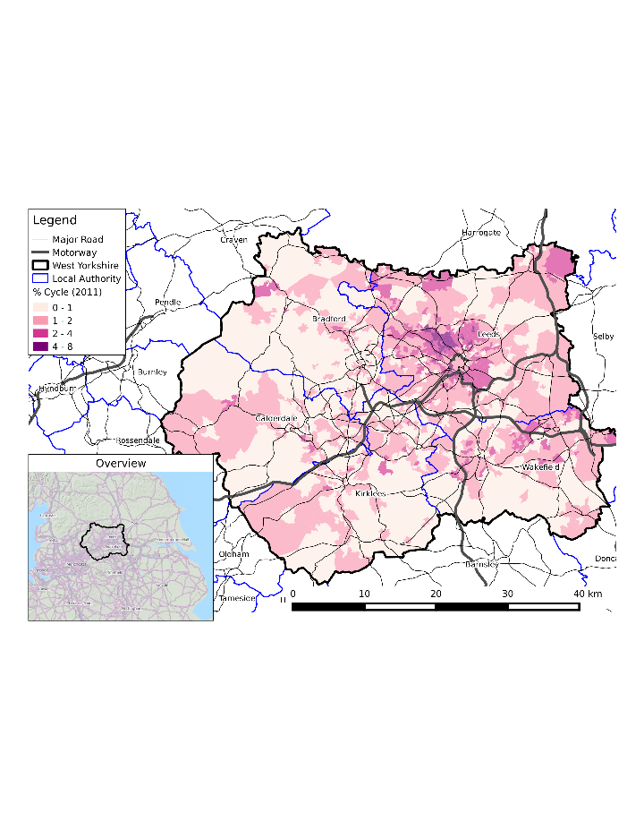

- Tour de France
- Targets for 10% of trips to be by bike following City Connect (WYCA)
- Definition of a crash as something reported in the STAT19 dataset. What is this specifically?

## Hypotheses

The hypotheses tested in this project were based on the literature on cyclist safety and fall into three broad categories: who, where and when.

A conceptual framework for developing hypotheses and inteventions around road safety was provided by Schepers et al. ([2014](http://www.sciencedirect.com/science/article/pii/S0001457513001309))…

### Who is most at risk from cycle incidents?

- Young adults (below 30) and the elderly (over 65) will be more likely to crash ([Martinez-Ruiz et al., 2014](http://www.sciencedirect.com/science/article/pii/S0001457513004089). We expected this trend to be stronger in more challenging cycling environments, on large roads.

### Where are crashes most likely to happen?

- We expected unusual and challenging features of urban infrastructure to be associated with higher than average rate of cycling than the rest of the road network. Following ([Vandenbulcke et al., 2014](http://www.sciencedirect.com/science/article/pii/S0001457513002686), we specifically expected clusters of incidents surrounding on-road tram tracks, bridges without cycling facilities, complex intersections and areas with a high traffic volume. Also based on this work, we expected cycle infrastructure to reduce risk.

### When are bicycle crashes most likely

# The data

The dataset for this study is the National STATS19 data on road traffic incidents. The data reports all incidents that took place between the 1st January 2005 until the 31st December 2012, providing 8 years of uninterrupted records. The structure of the raw dataset is itself quite complicated, divided into three main files:

- Accidents0512.csv, a 178 Mb file containing 1.3 million rows of data on the key attributes of each incident, including time and data, location (Easting and Northing is provided in OSGB1936 coordinates to the nearest 1 m, but rounded to the nearest 10 m in most cases), road type and other contextual variables such as weather.
- Casualty0512.csv, a 74 Mb file containing 1.8 million rows on the attributes of casualties from the incidents. These include reference to the vehicle, accident and socio-demographic information about those injured.
- Vehicles0512.csv, a 142 Mb file containing 2.5 million rows of data about the registered vehicles involved in the incidents. Variables include vehicle type and other vehicle attributes demographic details of the driver.

# Method

The analysis strategy was based on consideration of the data and the hypotheses we were aiming to test.

## Estimating exposure

A major methodological challenge faced by anyone trying to draw conclusions from road incident data is that the underlying level of exposure is usually unknown. Therefore, researchers can rarely tell if increases in crashes are due to change in the riskiness of an activity or whether simple increases in exposure - in this case an increase in cycle use in particular areas - is to blame.

The method used to estimate exposure varied depending on the hypothesis being tested by a particular technique.

# Results

Over the entire study period, the proportion of accidents involving cyclists was 8.1%, below the national average of 10.4%. These figure mask great variability in time and space.

There was clear seasonal pattern in the data, with a predominance of bicycle incidents during the summer months, presumably due to the increased uptake of cycling in warm and sunny weather (ref). Dividing the year into 4 quarters, it was found that the summer months (from April until September) were associated with a relatively high proportion of incidents involving cyclists (10.1% on average), compared with the colder half of the year (6.4%).

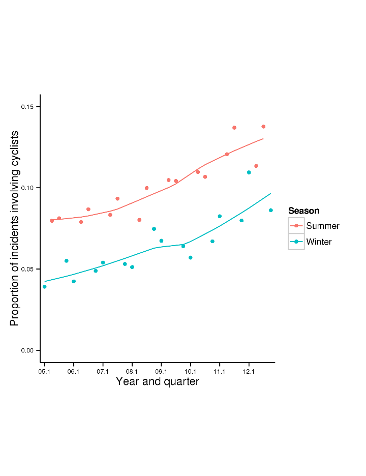

## The timing of bicycle accidents

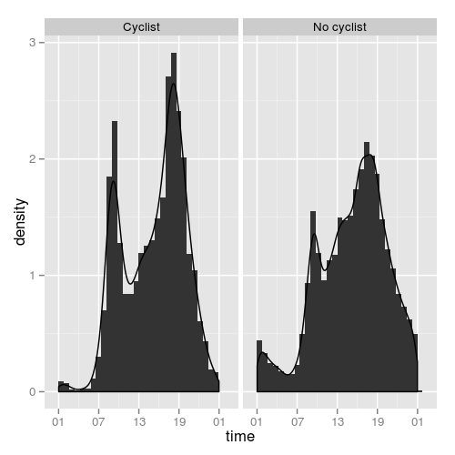

# Season

## Aspatial characteristics of cycle accidents (vs other roads accs)

# Discussion and conclusions

# References

Buehler, R. (2012). Determinants of bicycle commuting in the Washington, DC region: The role of bicycle parking, cyclist showers, and free car parking at work. Transportation Research Part D: Transport and Environment, 17(7), 525–531.

Elvik, R., Vaa, T., Erke, A., & Sorensen, M. (2009). The handbook of road safety measures. Emerald Group Publishing.

Fishman, E., Washington, S., & Haworth, N. (2012). Barriers and facilitators to public bicycle scheme use: A qualitative approach. Transportation Research Part F: Traffic Psychology and Behaviour, 15(6), 686–698. doi:10.1016/j.trf.2012.08.002

Martínez-Ruiz, V., Jiménez-Mejías, E., Luna-del-Castillo, J. D. D., García-Martín, M., Jiménez-Moleón, J. J., & Lardelli-Claret, P. (2014). Association of cyclists’ age and sex with risk of involvement in a crash before and after adjustment for cycling exposure. Accident; Analysis and Prevention, 62, 259–67. doi:10.1016/j.aap.2013.10.011

Parkin, J., Wardman, M., & Page, M. (2007). Models of perceived cycling risk and route acceptability. Accident; Analysis and Prevention, 39(2), 364–71. doi:10.1016/j.aap.2006.08.007

Schepers, P., Hagenzieker, M., Methorst, R., van Wee, B., & Wegman, F. (2014). A conceptual framework for road safety and mobility applied to cycling safety. Accident; Analysis and Prevention, 62, 331–40. doi:10.1016/j.aap.2013.03.032

Short, J., & Caulfield, B. (2014). The safety challenge of increased cycling. Transport Policy, 33, 154–165. doi:10.1016/j.tranpol.2014.03.003

Twisk, D. a M., & Reurings, M. (2013). An epidemiological study of the risk of cycling in the dark: the role of visual perception, conspicuity and alcohol use. Accident; Analysis and Prevention, 60, 134–40. doi:10.1016/j.aap.2013.08.015

Vandenbulcke, G., Thomas, I., de Geus, B., Degraeuwe, B., Torfs, R., Meeusen, R., & Int Panis, L. (2009). Mapping bicycle use and the risk of accidents for commuters who cycle to work in Belgium. Transport Policy, 16(2), 77–87. doi:10.1016/j.tranpol.2009.03.004

Vandenbulcke, G., Thomas, I., & Int Panis, L. (2014). Predicting cycling accident risk in Brussels: a spatial case-control approach. Accident; Analysis and Prevention, 62, 341–57. doi:10.1016/j.aap.2013.07.001

Wegman, F., Zhang, F., & Dijkstra, A. (2012). How to make more cycling good for road safety? Accident; Analysis and Prevention, 44(1), 19–29. doi:10.1016/j.aap.2010.11.010

## comments

```r
# data for lsoas from here https://www.nomisweb.co.uk/census/2011/qs701ew
# From abstract 'City Connect', a dedicated cycle path between Leeds and
# Bradford is at the forefront of this investment, and is associated with
# quantitative targets on both bicycle uptake and safety.
```